# A dive into the coral microbiome

Hadrien Gourlé

May 29, 2020

Coral reefs are one of the most diverse ecosystem on the planet.

They are economically vital for many people worldwide

They face great challenges and their population is rapidely declining.

# The coral microbiome

[figure not shown]

# Technologies to study the microbiome

## Sequencing

[figure not shown]

## Bioinformatics

[figure not shown]

# Why study the coral microbiome?

# Aims

- Improving methodology within the field of metagenomics
- Understanding coral-associated microbes better

# Simulating Illumina Metagenomic Data with InSilicoSeq

## Why?

why do we need simulated data?

[figure not shown]

## Why?

why do we need simulated data?

why do we need *yet another* simulation software?

## Results

Easily installable and usable

```bash
$ conda install insilicoseq
$ iss generate --ncbi bacteria -U 100 -n 10M \
    --model novaseq --cpus 8 --output reads
```

And used in the development of 10 published metagenomic software.

## Results

Kernel Density Estimation

[figure not shown]

## Results

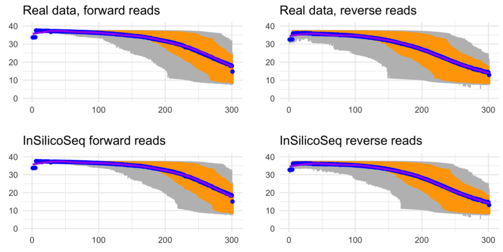

[figure not shown]

# A Data Driven Review of the Coral Microbiome

## The 16S gene and metabarcoding

[figure not shown]

## Methods

[figure not shown]

## Results

[figure not shown]

## Results

[figure not shown]

# Molecular Ecology of Coral Reef Microorganisms in the Western Indian Ocean coast of Kenya

## Methods

[figure not shown]

## Results

- 193 draft genomes recovered
- 12 million unique putative proteins

## Results

[figure not shown]

## Results

[figure not shown]

## Results

[figure not shown]

# Conclusion

- Warm water coral microbiomes are dominated by *Endozoicomonas*, but we are unsure what its role is
- Metagenomics allows insight into function, allowing to *dive* into the microbiome
- Coral bacteria are sensitive to pollution, and are promising potential markers for monitoring reef health and eventually inform policy making

# Future perspectives

## Methods

- Need for benchmarking is still there
- Automated metagenome binning methods have a lot of room for improvement

## Corals

- Whole metagenome sequencing on coral samples (SML)
- Monitoring antibiotic resistance in water